# Jan Walkiewicz - Projekt ryzyko kredytowe - Atlas

# Spis treści

1. Przygotowanie danych
2. Eksploracyjna analiza danych
3. Zależności między zmiennymi
4. Uzupełnianie danych
5. Tworzenie i trenowanie modeli
6. Sprawdzanie jakości modeli

# 1. Przygotowanie danych

## Sprzątamy dane

### Sprawdźmy pierw ilość, oraz typ naszych danych

## Zajmijmy się każdą kolumną z osobna

### 1. Kolumna id

#### Nie będzie nam potrzebna podczas naszej analizy, usuwamy ją.

### 2. Kolumna income

#### W kolumnie income lepiej sprawdzi się typ float, zmieńmy więc typ

### 3. Kolumna children

#### Zmieńmy także kolumne children na int

### 4. Kolumna credit_history

```
array(['dobra historia', 'brak historii', nan], dtype=object)
```

#### Możemy zauważyć, że wystepują tylko 2 typy wartości: "dobra historia" i "brak historii", zmieńmy, więc te wartości na wartości binarne.

TRUE - dobra historia

FALSE - brak historii

### 5. Kolumna overdue_payments

```
array(['brak opóźnień', nan, 'opóźnienia', '3', '2', '4'], dtype=object)
```

#### Możemy zobaczyć źle wpisane wartości: 3, 2 i 4. Są źle wpisane, więc musimy je usunąć.

```
array(['brak opóźnień', nan, 'opóźnienia'], dtype=object)
```

#### Teraz możemy zobaczyć, że wsytępują tylko 2 wartości, zamieńmy je więc na wartości binarne.

TRUE - opóźnienia

FALSE - brak opóźnień

### 6. Kolumna active_loans

#### Wszystko jest z nią w porządku :)

### 7. Kolumna years_in_job

#### Również wszystko okej :)

### 8. Kolumna employment_type

```
array(['samozatrudnienie', 'stała', 'brak', 'określona'], dtype=object)
```

#### W tej kolumnie użyjemy kodowania one-hot enconding

### 9. Kolumna owns_property

```
array([nan, 'tak', 'nie'], dtype=object)
```

#### Wsystępują, tylko wartości "tak" i "nie", zamieńmy je na wartości binarne "TRUE" i "FALSE".

tak - TRUE

nie - FALSE

### 10. Kolumna assets_value

#### Lepiej spradzi się typ float, zmieńmy więc typ na float.

### 11. Kolumna other_loans

#### Wszystko z nią w porządku :)

### 12. Kolumna education

```
array(['wyższe', 'średnie', 'podstawowe'], dtype=object)
```

#### Jako, że mamy tylko 3 rodzaje wykształcenia i wiemy, że wykształcenie średnie jest lepsze od podstawowego, oraz wyższe jest lepsze od średniego oznaczmy je za pomocą liczb w następujący sposób:

0 - podstawowe

1 - średnie

2 - wyższe

### 13. Kolumna city

```
array(['małe', 'średnie', 'duże'], dtype=object)
```

#### W tej kolumnie też mamy tylko 3 rodzaje miast, jednak nie możemy stweirdzić, że na przykład średnie miasta są lepsze od dużych. Skorzystamy więc z kodowania one-hot encodning.

### 14. Kolumna marital_status

```
array(['żonaty/zamężna', 'kawaler/panna', 'rozwiedziony/rozwiedziona'],
      dtype=object)
```

#### Sytuacja wygląda tak samo jak we wcześniejszej kolumnie, postępujemy dokładnie tak samo.

### 15. Kolumna support_indicator

#### Jest nam niepotrzebna, usuwamy ją.

Dane po zmianach wyglądają następująco:

```
<class 'pandas.core.frame.DataFrame'>
RangeIndex: 10000 entries, 0 to 9999
Data columns (total 22 columns):
 #   Column                                    Non-Null Count  Dtype
---  ------                                    --------------  -----
 0   age                                       10000 non-null  int64
 1   income                                    8000 non-null   float64
 2   children                                  10000 non-null  int64
 3   credit_history                            8000 non-null   object
 4   overdue_payments                          7260 non-null   object
 5   active_loans                              10000 non-null  int64
 6   years_in_job                              10000 non-null  int64
 7   owns_property                             8000 non-null   object
 8   assets_value                              8000 non-null   float64
 9   other_loans                               10000 non-null  int64
 10  education                                 10000 non-null  int64
 11  credit_risk                               10000 non-null  int64
 12  employment_type_brak                      10000 non-null  bool
 13  employment_type_określona                 10000 non-null  bool
 14  employment_type_samozatrudnienie          10000 non-null  bool
 15  employment_type_stała                     10000 non-null  bool
 16  city_duże                                 10000 non-null  bool
 17  city_małe                                 10000 non-null  bool
 18  city_średnie                              10000 non-null  bool
 19  marital_status_kawaler/panna              10000 non-null  bool
 20  marital_status_rozwiedziony/rozwiedziona  10000 non-null  bool
 21  marital_status_żonaty/zamężna             10000 non-null  bool
dtypes: bool(10), float64(2), int64(7), object(3)
memory usage: 1.0+ MB
```

# 2. Eksploracyjna analiza danych

### Rozkład zmiennych w zależności od ryzyka kredytowego

#### Ryzyko kredytowe

Pierwsze co należałoby zrobić to sprawdzić jak często dane ryzyka kredytowe występują.

Czy są one równomiernie rozłożone? A może któreś znacznie przeważa? Sprawdźmy to.

```
credit_risk
0    9675
1     325
Name: count, dtype: int64
```

Jak widać zdecydowana większość obserwacji w naszym zbiorze ma niskie ryzyko kredytowe, będziemy musieli to uwzględnić w niektórych wykresach.

Jest to mniej niz 3,5% naszych obserwacji

Przeprowadźmy dalszą analize aby lepiej zrozumieć rozkład ryzyk kredytowych.

#### Zmienne liczbowe

##### Pierwszą zmienną jaka przychodzi do głowy jeśli chodzi o ryzyko kredytowe są zarobki, sprawdźmy jak wygląda rozkład tej zmiennej.

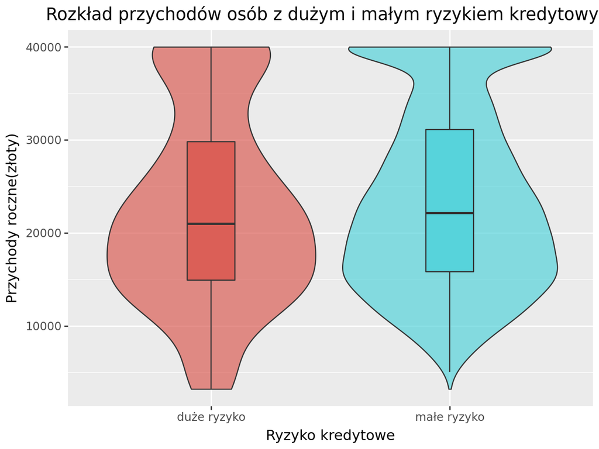

Wnioski płynące z wykresu są dosyć niespodziewane, gdyż zarobki osób z dużym ryzykiem kredytowym nie różnią się znacząco od tych z małym. Mediana również znacząco się nie różni.

Duże różnice widać jedynie na dole wykresu, przy zarobkach rocznych między 4, a około 8 tysięcy gdzie zauważono przewagę osób z dużym ryzykiem kredytowym. Oraz na przedziale przychodów około 37,5 tysiąca do 40 tysięcy jest zauważalna zdecydowana przewaga osób z małym ryzykiem.

Jak, więc możemy zauważyć jeśli zarobki oscylują między około 8 tysięcy, a 37,5 tysiąca (nie są wartością skrajną) nie ma to większego wpływu na ryzyko kredytowe.

Na wykresie widać także, że najwięcej osób w naszym zbiorze zarabia miedzy 15 tysięcy, a 20 tysięcy złotcyh rocznie.

##### A jak wygląda rozkład grup ryzyka kredytowego jeśli chodzi o wiek?

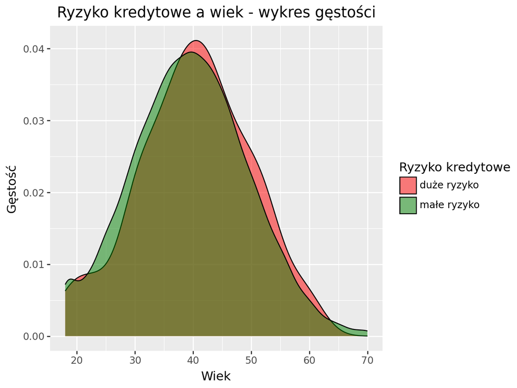

Jak widać na wykresie osoby do około 38 roku życia mają mniejsze ryzyko na nie spłacenie kredytu. Sytuacja ta zmienia się po ukończeniu tego wieku, wtedy wiek zaczyna działać na niekorzyść potencjalnego kredytobiorcy.

Na wykresie widać także, że nie ma większego znaczenia, jeśli chodzi o ryzyko kredytowe czy dana osoba ma 30 czy 35 lat (działa to w takim samym stopniu na korzyść). Analogicznie nie ma większej różnicy między 40 , 50, a 60 rokiem życia (wiek działa w każdym z tych przypadków tak samo na niekorzyść)

Możemy zobaczyć także jaki wiek najczęściej występuje w naszych danych. Jak widać jest to wiek około 40 lat.

##### Czy zatem wartość posiadanych aktywów ma duży wpływ na ryzyko kredytowe?

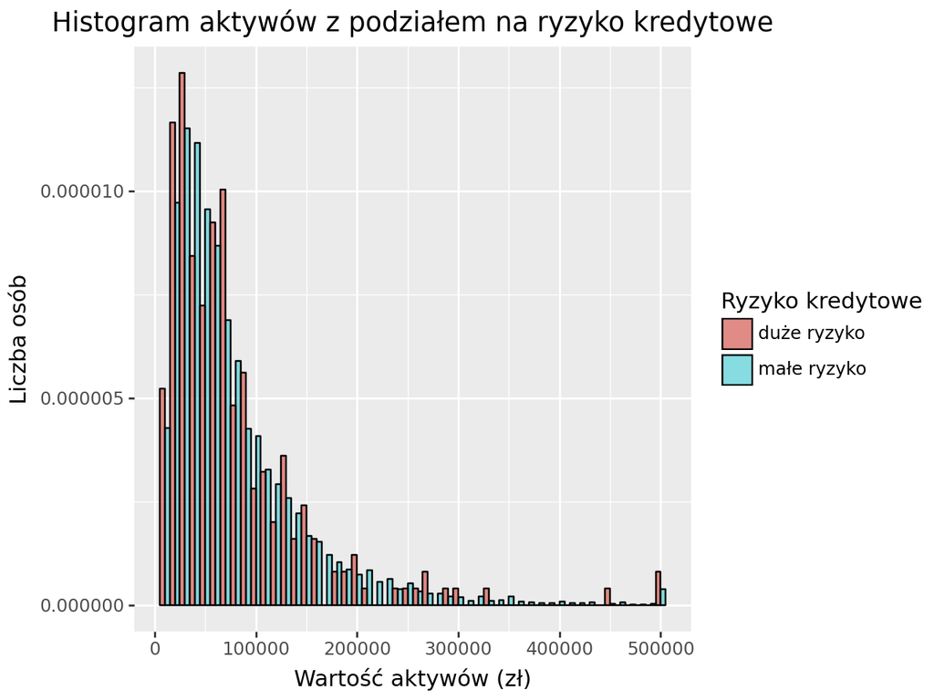

Jak widać na powyższym wykresie posiadanie aktywów "niczego nie gwarantuje". Nawet osoby posiadające aktywa powyżej 400 tysięcy są narażone na duże ryzyko kredytowe.

Wniosek, więc jaki z powyższego wykresu możemy wynieść jest następujący: Nie istnieje zbyt duża korelacja między wartościami aktywów, a ryzykiem kredytowym.

#### Zmienne kategoryczne

##### Wykształcenie, wielkość zamieszkałego miasta

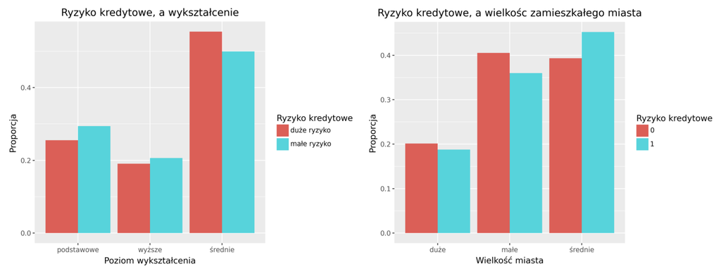

###### Wykształcenie

Jak można zobaczyć wykształcenie podstawowe, oraz wyższe w naszych danych daje większą szanse na małe ryzyko kredytowe niż wykształcenie średnie.

Ciekawą obserwacją jaką na powyższym wykresie można zauważyć jest fakt, że w naszej bazie więcej osób posiada wykształcenie podstawowe niż wyższe.

###### Wielkość zamieszkałego miasta

Jeśli chodzi o miasto zamieszkania widać, że osoby zamieszkujące średnie miasta mają zwiększone ryzyko kredytowe, podczas gdy w małych miastach szansa na duże ryzyko kredytowe jest mniejsza niż na wyższe.

Można również zauważyć, że w naszych danych zdecydowanie częściej ludzie zamieszkują małe oraz średnie miasta, a nie duże.

##### Historia kredytów, opóźnienie w płatnościach, typ zatrudnienia, posiadanie nieruchomości.

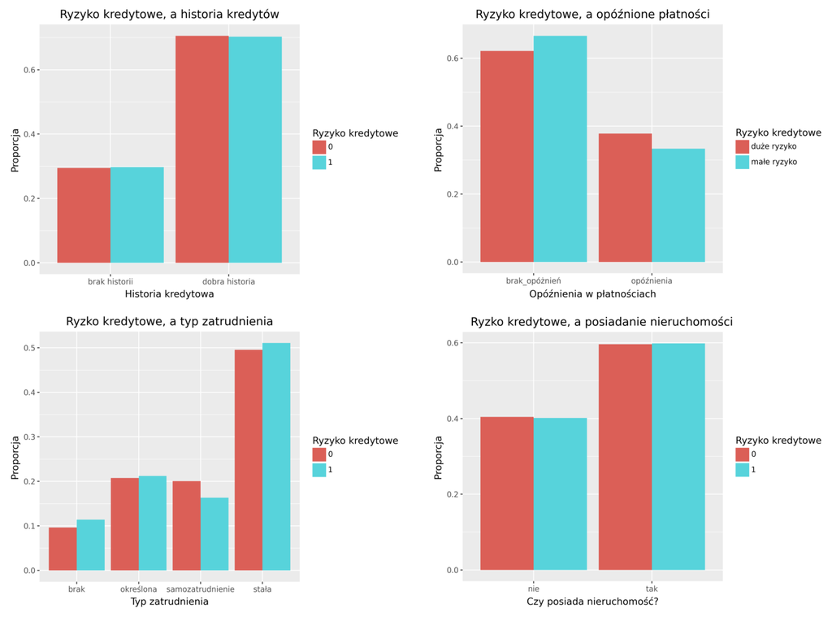

###### Historia kredytów

Widać także, że posiadanie dobrej historii kredytowej naprawdę niewiele zwiększa szanse na małe ryzyko kredytowe w porównaniu do osób które tej historii nie mają.

Można zaobserwować, że w naszych danych nie wsytępuje ani jedna obserwacja ze złą historią kredytową.

Zdecydowanie więcej obserwacji posiada dobrą historie kredytową, niż jej brak.

###### Opóżnienia w płatnościach

Widać istniejącą korelacje, obserwacje z opóźnieniem w płatnościacj mają zwiększone ryzyko kredytowe.

Opóźnienia w płatnościach ma mniej niż 40% obserwacji.

###### Typ zatrudnienia

Brak zatrudnienia najbardziej zmniejsza szanse na zakwalifikowanie obserwacji jako obserwacji z małym ryzykiem kredytowym. Stałe zatrudnienie również działa na niekorzyść danej obserwacji. Mocno na korzyść działa samozatrudnienie.

Około 50% obserwacji posiada stałą prace, a najmniej popularne jest brak zatrudnienia.

###### Posiadanie nieruchomości

Jak widać posiadanie nieruchomości nie zwiększa znacząco szansy na małe ryzyko kredytowe.

Około 60% obserwacji posiada nieruchomość.

# 3. Zaleznosci miedzy zmiennymi

### Zmienne liczbowe

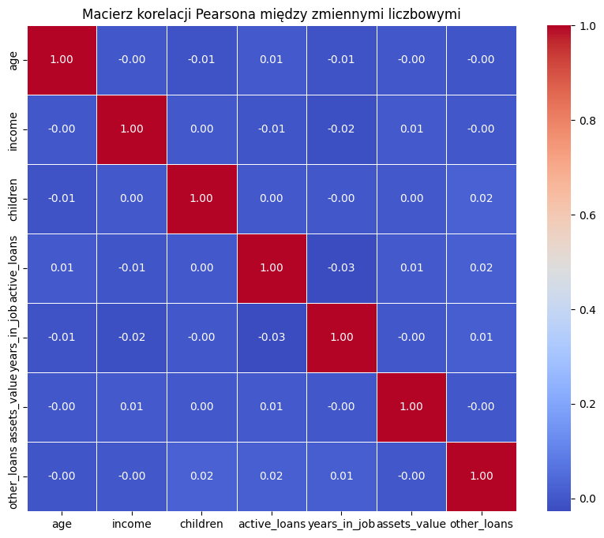

W korelacji Pearsona wartości korelacji wahają się od -1 do 1. Wartości bliskie 1 oznaczają silną korelację pozytywną, wartości bliskie -1 oznaczają silną korelację negatywną, a wartości bliskie 0 oznaczają brak korelacji.

Na podstawie macierzy korelacji Pearsona widać, że zmienne liczbowe nie są ze sobą istotnie skorelowane.

### Zmienne kategoryczne

```
Tabela wartości p dla testu chi-kwadrat:
                 credit_history overdue_payments employment_type  \
credit_history             None         0.442519        0.805528
overdue_payments       0.442519             None        0.657547
employment_type        0.805528         0.657547            None
owns_property          0.075578         0.077606        0.392405
education              0.553004         0.862194        0.843523
city                    0.21048         0.360595        0.588482
marital_status         0.212989         0.977332        0.197273

                 owns_property education      city marital_status
credit_history        0.075578  0.553004   0.21048       0.212989
overdue_payments      0.077606  0.862194  0.360595       0.977332
employment_type       0.392405  0.843523  0.588482       0.197273
owns_property             None  0.476398  0.748159       0.085492
education             0.476398      None  0.006518        0.38179
city                  0.748159  0.006518      None       0.686626
marital_status        0.085492   0.38179  0.686626           None
```

# 4. Uzupelnianie danych

Jeśli chcielibyśmy usunąć wiersze z brakującymi danymi byłoby to na pewno ponad 27% naszych danych, gdyż w samej kolumnie "overdue_payments" ponad 27% wartości jest brakujących. Musimy, więc te dane uzupełnić jest ich zdecydowanie za dużo żeby myśleć o usuwaniu brakujących wartości.

### zmienne liczbowe

```
<class 'pandas.core.frame.DataFrame'>
RangeIndex: 10000 entries, 0 to 9999
Data columns (total 22 columns):
 #   Column                                    Non-Null Count  Dtype
---  ------                                    --------------  -----
 0   age                                       10000 non-null  int64
 1   income                                    8000 non-null   float64
 2   children                                  10000 non-null  int64
 3   credit_history                            8000 non-null   object
 4   overdue_payments                          7260 non-null   object
 5   active_loans                              10000 non-null  int64
 6   years_in_job                              10000 non-null  int64
 7   owns_property                             8000 non-null   object
 8   assets_value                              8000 non-null   float64
 9   other_loans                               10000 non-null  int64
 10  education                                 10000 non-null  int64
 11  credit_risk                               10000 non-null  int64
 12  employment_type_brak                      10000 non-null  bool
 13  employment_type_określona                 10000 non-null  bool
 14  employment_type_samozatrudnienie          10000 non-null  bool
 15  employment_type_stała                     10000 non-null  bool
 16  city_duże                                 10000 non-null  bool
 17  city_małe                                 10000 non-null  bool
 18  city_średnie                              10000 non-null  bool
 19  marital_status_kawaler/panna              10000 non-null  bool
 20  marital_status_rozwiedziony/rozwiedziona  10000 non-null  bool
 21  marital_status_żonaty/zamężna             10000 non-null  bool
dtypes: bool(10), float64(2), int64(7), object(3)
memory usage: 1.0+ MB
```

Jako, że udowodniliśmy już niezależność zmiennych liczbowych między sobą, oraz nie mamy dużej ilości wartości odstających dane te uzupełnijmy średnią.

```
23598.62125
80349.42025
```

Nasza średnia z wartości przychodów wynosi 23598.62125, a średnia wartość posiadanych aktywów 80349.42024(9) i to tymi wartościami uzupełniamy puste braki daych.

### Zmienne kategoryczne

W zmiennych kategorycznych braki występują w kolumnach "credit_history", "overdue_payments", "owns_property".

Jako, że udowodniliśmy już niezależność wartości kategorycznych między sobą. Braki uzupełnimy losowo na podstawie proporcji występowania każdej kategorii w zmiennej.

```
age                                         0
income                                      0
children                                    0
credit_history                              0
overdue_payments                            0
active_loans                                0
years_in_job                                0
owns_property                               0
assets_value                                0
other_loans                                 0
education                                   0
credit_risk                                 0
employment_type_brak                        0
employment_type_określona                   0
employment_type_samozatrudnienie            0
employment_type_stała                       0
city_duże                                   0
city_małe                                   0
city_średnie                                0
marital_status_kawaler/panna                0
marital_status_rozwiedziony/rozwiedziona    0
marital_status_żonaty/zamężna               0
dtype: int64
```

Jak widać uzupełniliśmy wszystkie brakujące braki danych.

# 5. Tworzenie i trenowanie modeli

### Maszyna wektorów nośnych SVM

### Naiwny klasyfikator Bayesa

# 6. Sprawdzanie jakosci modeli

|  | Model | Accuracy | Recall | Specificity |
| --- | --- | --- | --- | --- |
| 0 | DT | 0.96 | 0.53 | 0.98 |
| 1 | RF | 0.98 | 0.48 | 1.00 |
| 2 | SVM | 0.96 | 0.00 | 1.00 |
| 3 | NB | 0.96 | 0.00 | 1.00 |
| 4 | XGB | 0.98 | 0.46 | 1.00 |

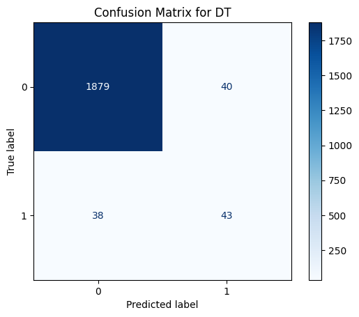

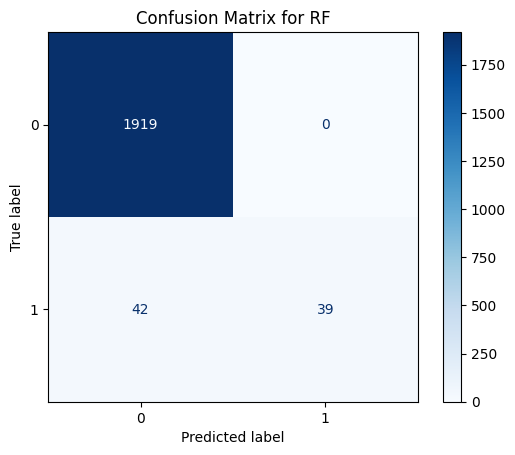

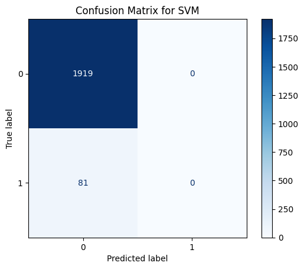

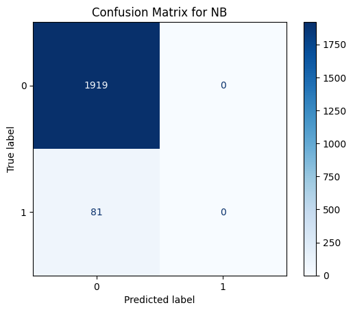

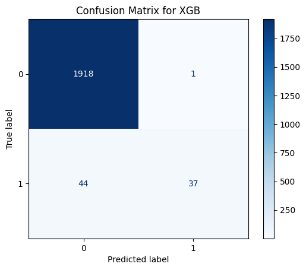

Jak możemy zobaczyć w naszym przypadku najlepiej sprawdził się model lasu losowego :)